# IODS course project

Tuukka Oikarinen

# Introduction to Open Data Science - Course Project

# About the project

```r
# This is a so-called "R chunk" where you can write R code.

date()
```

```
## [1] "Sun Dec 11 20:56:48 2022"
```

I am feeling excited to learn a lot! I am a bit worried if I will manage to work through every week as I am not so familiar with all the techniques. But I will try my best, and ask help, if needed! I took this course as it could fit well to my study programme in Social Data Science - program.

I briefly looked through RStudio exercise. I just completed course on the same book (Quantitative Research Skills by Kimmo), so I felt confident enough to not go through the exercise in detail. But thank you for it, it is always useful to have materials.

My github repo: https://github.com/tuoikari/IODS-project

# 2: Regression and model validation

```r
date()
```

```
## [1] "Sun Dec 11 20:56:48 2022"
```

Here we go again…

First, let’s load all the libraries.

```r
library(ggplot2)
library(GGally)
library(tidyverse)
```

Just to make sure that my data is correct, I load the data from the web address (even though I think that my wrangling was successful).

```r
#read in data
lrn14_chapter2 <- read.table("https://raw.githubusercontent.com/KimmoVehkalahti/Helsinki-Open-Data-Science/master/datasets/learning2014.txt", sep=",", header=TRUE)
```

Explore the data:

```r
str(lrn14_chapter2)
```

```
## 'data.frame':    166 obs. of  7 variables:
##  $ gender  : chr  "F" "M" "F" "M" ...
##  $ age     : int  53 55 49 53 49 38 50 37 37 42 ...
##  $ attitude: num  3.7 3.1 2.5 3.5 3.7 3.8 3.5 2.9 3.8 2.1 ...
##  $ deep    : num  3.58 2.92 3.5 3.5 3.67 ...
##  $ stra    : num  3.38 2.75 3.62 3.12 3.62 ...
##  $ surf    : num  2.58 3.17 2.25 2.25 2.83 ...
##  $ points  : int  25 12 24 10 22 21 21 31 24 26 ...
```

```r
dim(lrn14_chapter2)
```

```
## [1] 166   7
```

The dataframe contains 166 rows/respondents and 7 columns/variables. The variables are: “Gender”, “Age”, “attitude”, “deep”, “stra”, “surf” and “points”. Most of the columns are numerical and integers, but gender is characher variable. The data set contains those students whose scores where higher than 0. Deep, stra and surf -variables relate to deep, strategic and surface learning strategies that very examined in the study. Attitude refers to “Global attitude toward statistics”. If I understood correctly, the value is counted by summing together questions about statistics. The column in this data frame was further divided by ten because it “is scaled back to the original scale of the questions, by dividing it with the number of questions” (Quatation is from the “Exercise2.Rmd”).

Scatter matrix of the variables in data (other than gender)

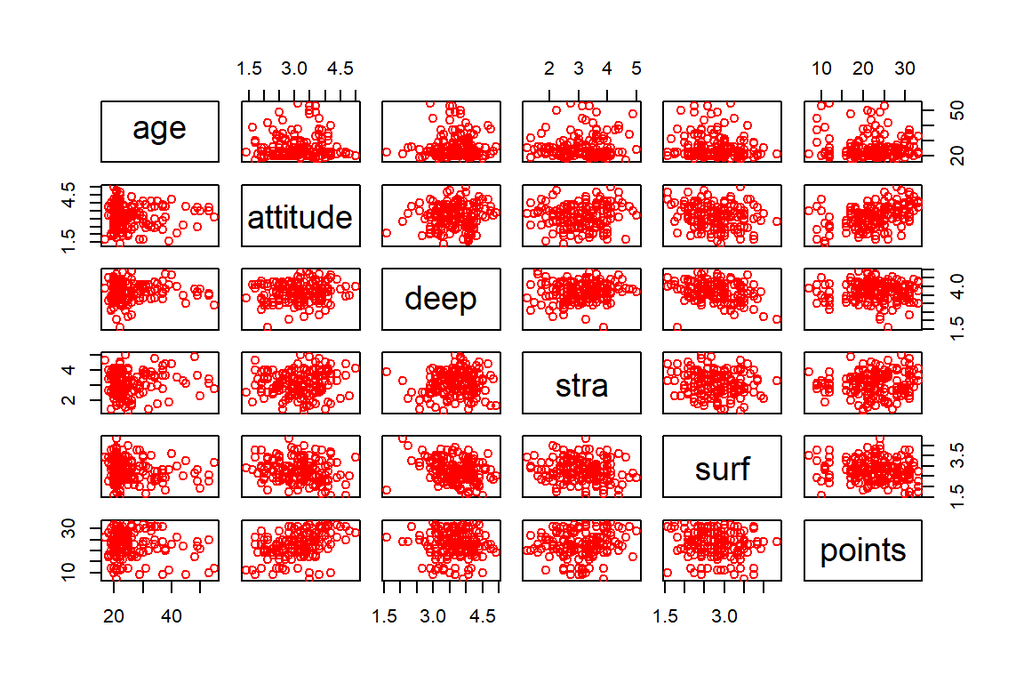

```r
#Draw a scatter matrix of the variables in learning2014 (other than gender)
pairs(lrn14_chapter2[-1], col = "red")
```

Let’s create a more advanced plot matrix with ggpairs()

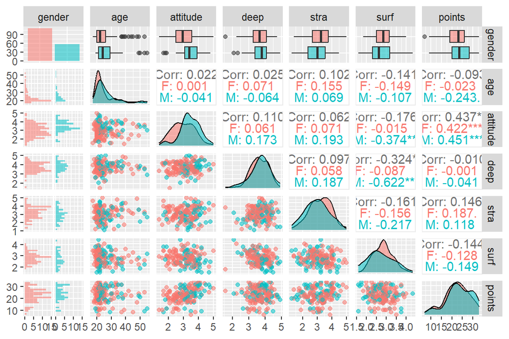

```r
plot2 <- ggpairs(lrn14_chapter2, mapping = aes(col=gender, alpha = 0.3), lower = list(combo = wrap("facethist", bins = 20)))
plot2
```

I don’t know what gender is what in this plot so I will quickly look at count of gender groups in this data set.

```r
lrn14_chapter2 %>%
    group_by(gender) %>%
    count()
```

```
## # A tibble: 2 × 2
## # Groups:   gender [2]
##   gender     n
##   <chr>  <int>
## 1 F        110
## 2 M         56
```

So, in the plot above, red color is female and mint color is male. But now that I look into the plot, it has the letter with the colors below, so this step was not neede after all. Anyway, it is nice to know the distribution of gender counts in this data set (which also happens to be in the plot above). In the ggpairs() plot one can see histograms of every variable, grouped by the genders. In the plot Pearson correlation value and significance are also displayed. For example, one can see that attitude and points are quite strongly (0.437 with high significance) positively correlated. When on the other hand, surface learning and deep learning are quite strongly negatively correlated with pretty good significance level (**). Age and deep learning don’t seem to correlate strongly, but there is not significance level reported on the plot (or not visible on the picture on my device).